# Climate Test

Rating the Climate Readiness of Fishery Management Options

Tom Carruthers tom@bluematterscience.com

16 January, 2026

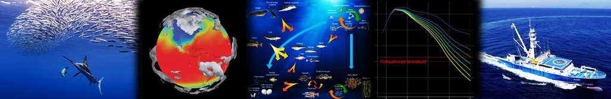

[figure not shown]

# 1 Overview

Forecasts of climate impacts on marine populations have often struggled to pass peer-review. Typically, those forecasts are also highly uncertain. These forecasting challenges have proven an impediment to the adoption of fishery management practices that are considerate of climate change.

To alleviate the need for a defensible forecast, the Climate Test rephrases the problem, focusing on the relative performance of management options given increasingly extreme climate scenarios. This is analogous to testing pilots in a simulator. It is possible to simulation test and then rate pilots according to their ability to fly under increasingly challenging weather conditions. This pilot rating process is unrelated to a particular weather forecast.

The aim of Climate Test is to provide strategic information to fishery managers about the relative climate robustness of various candidate management options. For a set of candidate management procedures that are otherwise comparable, managers have the option of adopting a procedure that has been shown to withstand more extreme climate tests.

# 2 Project Details

Title: ‘Creating and demonstrating a practical, science-based framework that enables fisheries managers to evaluate and adopt climate-resilient management procedures’

| Term | Sept 2025 - Nov 2027 |
| --- | --- |
| Funded by | Paul M. Angell Family Foundation, Oceankind, The Pew Charitable Trusts |
| Coordinated by | The Ocean Foundation (TOF) |
| Initiative | www.HarvestStrategies.org |
| Project Partners | Blue Matter Science Ltd., University of Cape Town (UCT) |
| TOF Project Leader | Rebecca Scott |
| Blue Matter Team | Tom Carruthers, Adrian Hordyk, Quang Huynh |
| UCT Collaborators | Kelly Ortega-Cisneros, Carryn de Moor |

# 3 Introduction

## 3.1 Hypothesized Climate Impacts on Exploited Marine Populations

Changing climatic conditions have the potential to substantially alter the abundance, productivity and species composition of pelagic marine ecosystems (Beaugrand and Kirby 2023, Bell et al. 2011). Due to increasing anthropogenic greenhouse gas emissions, climate processes affecting marine ecosystems are forecasted to intensify (Hoehy-Guldberg et al. 2018; Kwiatkowski et al., 2020).

Climate processes (e.g., thermal regime, concentration of greenhouse gasses) are linked to oceanographic conditions (e.g., ocean temperature, ocean mixing, stratification, pH & salinity)(Figure 1, Table 1). A large number of mechanisms have been proposed for how individual fish stocks may be impacted by those changing oceanographic conditions (Table 2). The mechanistic linkages are numerous and can relate to changing ecological processes (e.g., primary productivity, community dynamics) and the location and amount of suitable habitat. The large number of mechanisms ultimately impact a relatively concise list of individual stock dynamics relating to species distribution, survival of various life stages, condition factor, fecundity and somatic growth (Walther et al., 2002; Doney et al., 2012; Free et al., 2019).

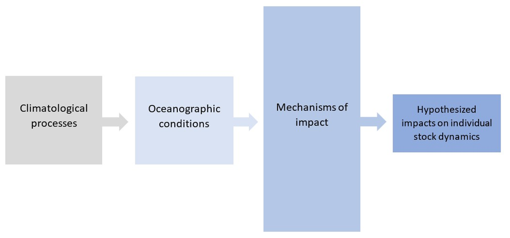

Figure 1. A simplified diagram of linkages among climate processes, oceanographic conditions and individual species dynamics. The size of each box is intended to represent the relative number of processes / mechanisms that have been proposed in the literature, highlighting the relatively small number of hypothesized impacts on individual species.

In their review of impacts on large pelagic fish in the Northwest Atlantic, Dell’Apa et al. (2023) provide a useful example of changes in ocean conditions that may impact stock dynamics:

“… the Northwest Atlantic Ocean has been characterized by several climate-driven changes in regional environmental conditions over recent decades, including warmer sea surface temperature (SST) (Karnauskas et al., 2013; Loder and Wang, 2015) and bottom water temperature (Brickman et al., 2018), increased summertime stratification of shelf waters (Li et al., 2015), changes in dissolved oxygen concentration (DO) levels (Stendardo and Gruber, 2012) and acidification (Cai et al., 2011), and altered oceanographic processes (Karnauskas et al., 2015)”.

Establishing climate-ready management is a key priority for many regional fishery management organizations in light of persistent declines in various species (Pacoureau et al. 2021) and concern that fishing may increase the sensitivity of marine populations to climate change (Hsieh et al. 2008).

Evaluating the climate-readiness of current and alternative management options requires models that can predict fishery and population dynamics. Unfortunately, forecasting the impacts of climate changes on managed pelagic species is highly uncertain. In theory, it is possible for example, to combine models of emissions (e.g., Algieri et al. 2023, Wang et al. 2017), earth systems (Kawamiya et al. 2020), ecosystems (e.g., Beaugrand and Kirby 2018, Lehodey et al. 2010; 2011), behaviour (e.g., Bushnell and Brill 1991, Cayré and Marsac 1993) and physiology (e.g., Gooding et al. 1981, Graham et al. 1989, Essington 2003, Checkley et al. 2009). In doing so, forecasting combines a complex series of linked projections that include greenhouse gas emissions (least uncertain), response of climate processes (uncertain), linkages with oceanographic conditions (more uncertain) and the expected impact of those on pelagic communities and individual species (most uncertain). It follows that any climate change scenario for establishing climate-ready management advice for a given fish stock is firmly hypothetical, and the relative credibility of scenarios should be considered highly uncertain.

Table 1. Proposed linkages between climatological processes and oceanographic properties impacting fish habitat.

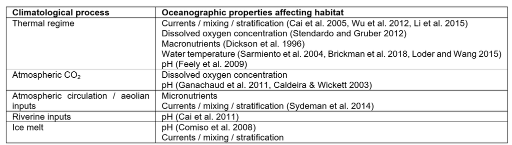

This large uncertainty over climate impact scenarios poses a problem for the provision of ‘climate ready’ fishery management advice using the contemporary stock assessment and management strategy evaluation (MSE) frameworks. That is because those frameworks rely on the specification of models that represent climate impacts and the assigned credibility of those models could strongly affect the advice provided. For example, there may be small or large future changes in natural survival. Advice arising from scenarios with low survival changes would likely lead to the provision of strongly differing advice from scenarios with high natural survival, yet the relative credibility of those scenarios is not easily evaluated.

Although there are very few quantitative forecasts of climate impacts on fisheries, qualitatively the way in which climate can impact individual populations has been hypothesized in numerous papers (Table 2). The most frequently hypothesized population changes relate to recruitment (carrying capacity, spawning habitat, larval survival), adult survival (natural mortality rate), somatic growth, spatial distribution (range contraction, catchability) age-at-maturity and condition factor (weight-at-length, fecundity). Additionally, the problematic direction of change in those variables is established: lower recruitment strength, decreased survival, lower somatic growth rate, reduced spatial distribution, older age-at-maturity and poorer condition factor. The incredibly large body of theoretical work is distilled into a very small set of single stock climate impacts.

Table 2. Mechanistic linkages between oceanographic properties impacting fish habitat and the dynamics of individual stocks (or operating models).

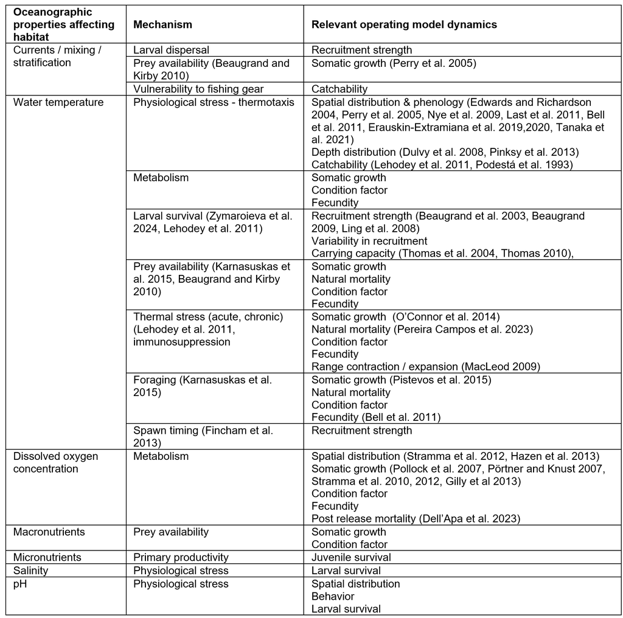

## 3.2 Climate Test: Metrics of Climate Robustness

Rather than leaving the investigation of climate resilience stalled in the (perhaps indefinite) wait for scientifically defensible forecasts of climate impacts, the Climate Test presents an alternative approach. The solution proposed here is to shift the focus from forecast-based tests of climate robustness in favor of performance metrics of climate robustness. This is analogous to testing pilots in a simulator under an increasingly difficult set of weather conditions. We do not need a weather forecast to know those pilots that are better at flying in more extreme weather conditions. The Climate Test increases the degree of climate impact to identify those management options that are most robust.

## 3.3 Management Strategy Evaluation

The Climate Test is proposed as an extension to management strategy evaluation (MSE), a process that has two essential components for climate test already specified: (1) models of system dynamics (operating models) and (2) candidate management options (management procedures, harvest strategies). The intention of Climate Test is to be a straightforward addition to any MSE process established in the openMSE framework (an extension R package) allowing for climate-considerate management advice in more than 20 current MSEs.

# 4 Methods

## 4.1 Robustness Threshold

The climate test compares when management options ‘break’ due to climate impacts and hence requires a definition of that break point, a ‘Robustness threshold’. The Robustness threshold has three parts: (1) an unacceptable level of impact, (2) a quantity that is impacted and (3) a time horizon.

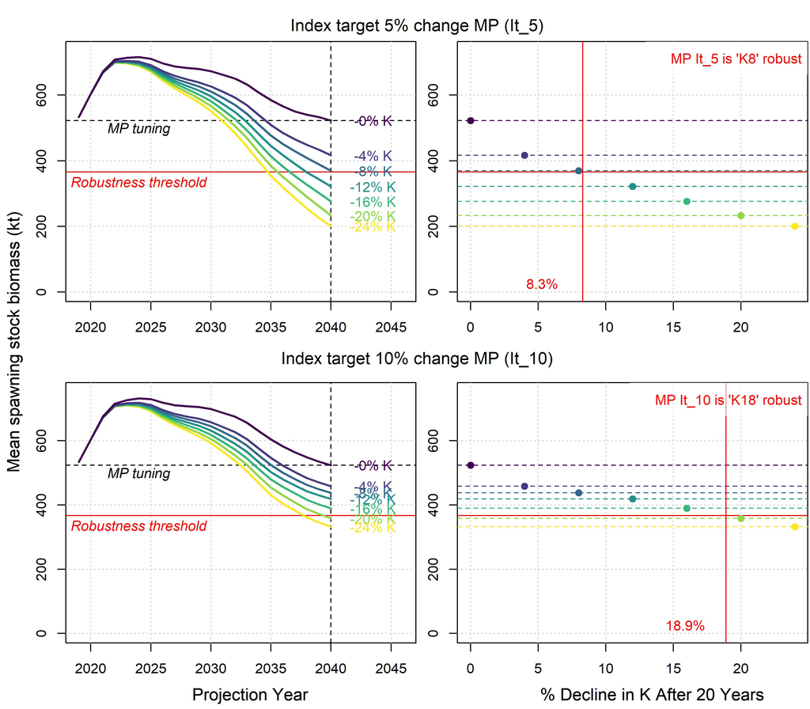

Figure 2. An exploratory climate test of decreasing somatic growth for two management procedures applied to Atlantic blueshark operating model (Carruthers 2024b)

## 4.2 Exploratory Tests

| Parameter | Code | Description |
| --- | --- | --- |
| Somatic Growth | K | Declines in somatic growth may lead to fewer mature fecund individuals in the population, a higher fraction of fish caught per catch weight, and a lower rate of sustainable harvest |
| Recruitment Strength | R | Declines in recruitment strength require fewer catches to maintain stock sizes |
| Natural Mortality | M | Declining natural survival (increasing M) reduces the number of cohorts in the population, and reduces the likelihood of reaching maturity |
| Condition Factor | C | Declining condition factor reduces spawning biomass, increases the number of fish caught per catch weight and reduces the rate of sustainable harvest |
| Spatial distribution | S | Spatial range contraction towards fishing can increase catchability (fishing efficiency) leading to higher catch per effort and hyperstability in relative abundance indices |

These marginal climate tests can be used to rate MPs according to the level of climate impact before the robustness threshold is crossed. Table 4 shows four marginal tests for six example management procedures for Atlantic Blue Shark (Carruthers 2024b).

Table 4. An example of exploratory climate tests of decreasing: natural survival (M), mean recruitment strength (R), condition factor (C) and somatic growth (K) for six generic management procedures applied to a Atlantic blueshark operating model (Carruthers 2024b). Numbers represent the percentage change in each exploratory test before the robustness threshold was crossed. Higher numbers indicate higher impacts and hence a more climate robust management procedure.

[interactive table not shown]

## 4.3 Conceptual Test

Conceptual tests differ from exploratory tests in that they use a theoretical model to predict the combined impacts of climate at the same time. For example, rather than separately rating MP robustness given increasing the natural mortality rate (M) and reductions in somatic growth (K), the conceptual test makes a paired projection of these parameters, linking them by a theoretical ecosystem model.

[interactive chart not shown]

Figure 3. An example of three individual future projections of natural mortality rate (M, increasing) and somatic growth rate (K, decreasing). In this example, made-up for didactic purposes, the two parameters are negatively correlated, and constrained theoretically by the equations of the ecosystem model. The three lines represent three individual projections at low, medium and high climate impacts (green, orange, red). Changes are phrased as a mulitple of current levels (e.g. they start at 1 in 2024).

[interactive chart not shown]

Figure 4. As Figure 3 but including the projected values of 10 simulations combined.

In combined tests, all parameters change with increasing climate impact so results are easily presented graphically along a continuum of climate impact (Figure 5).

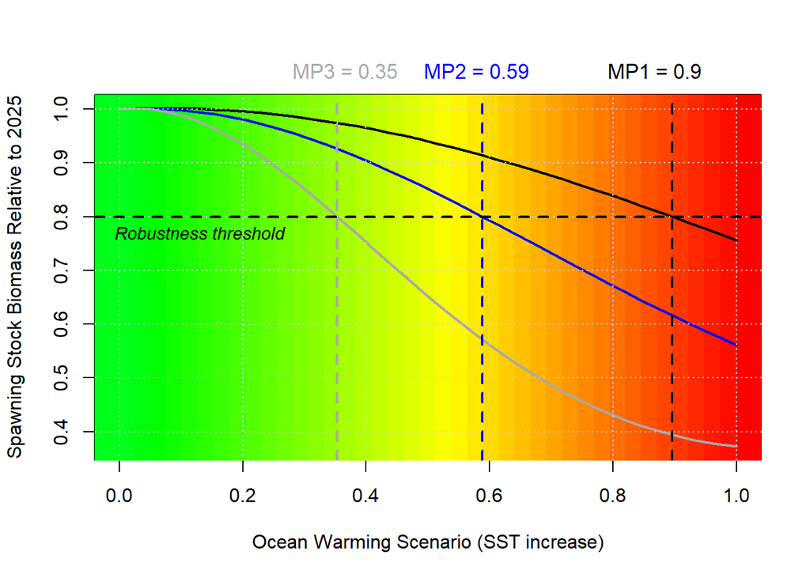

## 4.4 Tailored Test

Tailored tests are identical to conceptual tests but they are based on ecosystem models specified and calibrated for the particular case study stock. For example, the conceptual test might apply model-based projections for a lower trophic level pelagic fish stock. The tailored test could be based on, for example, impacts on natural mortality, growth and recruitment for Sarding in an Atlantis ecosystem model for the Benguela Ecosystem.

# 5 Using Climate Test

## 5.1 Overview

There are four distinct steps to conducting a Climate Test for any given case study:

1. Prepare operating models to have no climate change impacts
2. Tune candidate management procedures so they have identical outcomes given no climate impacts
3. Test the MPs over increasingly stringent climate impacts
4. Summarize results

These steps are connected:

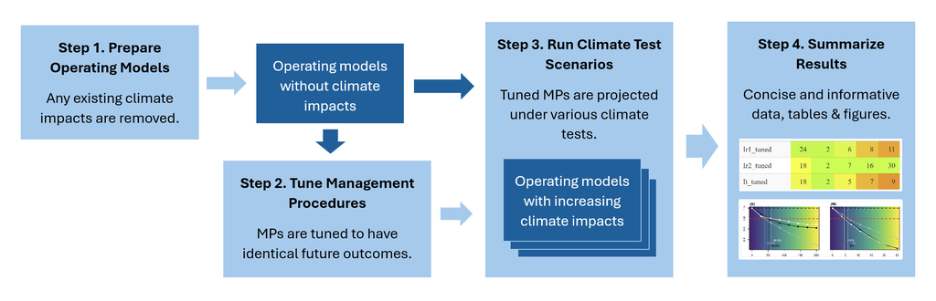

Step 3. In the third step various escalating climate impacts are imposed on the operating models. The tuned MPs are projected in these simulated conditions generating predicted yield and SSB outcomes (amongst many other outputs).

Step 4. The fourth step analyses these projected data to evaluate the climate robustness of the tuned MPs. For example, by calculating the level of climate impact before an MP crosses a specified Robustness Threshold. This could be 80% of current SSB in projection year 30. For example, if MPs 1 and 2 cross the robustness threshold given 4% and 8% increases in natural mortality rate over 30 years we might say MP 2 is twice as climate robust as MP 1. We could derive a language based on this robustness such as ‘M4’ and ‘M8’ robust.

The rest of this section goes into detail on how to carry out the Climate Test in code, for a real application.

## 5.2 Installation

### 5.2.1 R and RStudio

Climate Test uses the R statistical environment and the openMSE libraries to manipulate operating models, management procedures and conduct closed-loop simulations. To start it is recommended that you install the latest versions of R and RStudio.

R can be downloaded from the [R Project for Statistical Computing webpage](https://cloud.r-project.org/).

Currently the ClimateTest package is compatible with R version R version 4.5.1 (2025-06-13 ucrt).

RStudio can be downloaded from the [Posit webpage](https://www.rstudio.com/).

Currently the ClimateTest package is working in RStudio version 2025.05.1 Build 513.

The ClimateTest package has only been tested on a Windows x64 system.

### 5.2.2 Installing R Packages

Open RStudio and run the following lines of code at the R command prompt:

```r
install.packages("remotes")
remotes::install_github('blue-matter/ClimateTest')
```

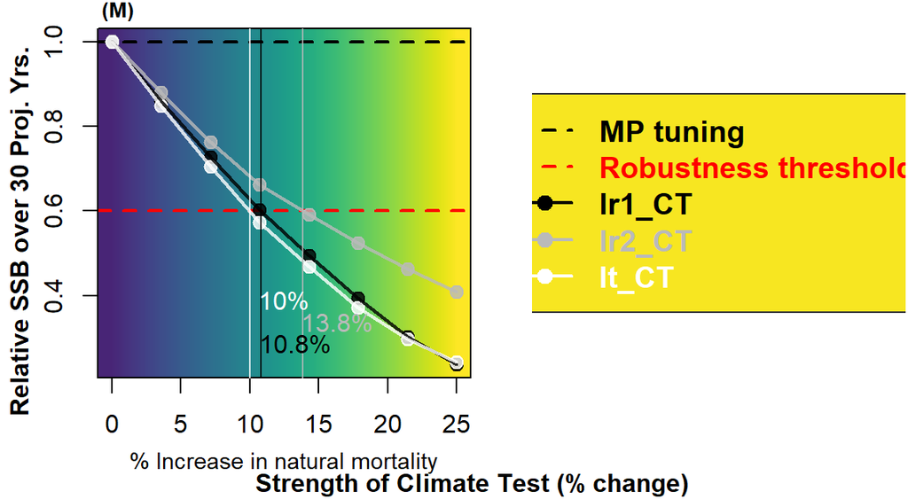

```r
library(ClimateTest)
CT_4_summary(CT_data, tests = "M", RT = 0.6, horizon = 30)
```

## 5.3 Demonstration Using OM annd MPs of the ClimateTest Package

### 5.3.1 Prerequisites

To start using ClimateTest functions you need to load up the library and initialize a cluster on your computer for parallel processing. Parallel processing is important because ClimateTest is very computationally demanding, involving numerous simulated projections of stock dynamics in the tuning of management procedures and the testing of climate robustness.

```r
library('ClimateTest')        # ClimateTest functions and demo objects
packageVersion('ClimateTest') # Check ClimateTest version
setup()                       # Set up parallel processing
```

### 5.3.2 Examine Demonstration Operating Models and Management Procedures

The ClimateTest R package comes with small (few simulations) operating models and fast (empirical) management procedures that are ideal for demonstrating the various steps of the Climate Test approach.

You can list these objects using the objs() function:

```r
objs('MP')                   # Generic management procedures
```

```
## Searching for objects of class MP in package: ClimateTest
```

```
##  [1] "CE_b"    "CE_c"    "CE_d"    "CE_e"    "Ir"      "It"      "MCC11_b"
##  [8] "MCC11_c" "MCC11_d" "MCC11_e" "MCC9_b"  "MCC9_c"  "MCC9_d"  "MCC9_e"
```

```r
objs('OM')                   # Demo operating models
```

```
## Searching for objects of class OM in package: ClimateTest
```

```
## [1] "BET_1" "BET_2" "BSH_1" "BSH_2"
```

Here we can see two example operating models based on recent stock assessments of Bigeye Tuna (BET) and Blue Shark (BSH) in the North Atlantic Ocean.

There are two operating models for each species, the first is the base model derived directly from the recent Stock Synthesis 3 assessment for those stocks. The second (e.g. BET_2, BSH_2) is identical but has a lower level of resilience (Beverton Holt stock-recruitment steepness value is lower).

The example management procedures are empirical (i.e. do not include models that estimate stock and fishery dynamics) and aim for a constant harvest rate (Index-ratio, ‘Ir’, a constant ratio of TAC to relative abundance index level) or a target index level (Index-target, ‘It’, a specified level of a relative abundance index).

To learn more about the management procedures and operating models you can call up the in-line R help:

```r
?Ir        # Help documentatation for the Index-ratio empirical MP included in the ClimateTest package
?BET_1     # Help documentatation for the N. Atl. Bigeye operating model included in the ClimateTest package
```

### 5.3.3 Step 1, Prepare Operating Models

A user defined list of operating models (openMSE class ‘OM’ or ‘MOM’) are standardized to have no climate impacts, returning the historical simluations spooled-up for projections.

```r
OM_list = list(BET_1, BET_2)       # A list of operating models
Hist_list = CT_1_prep(OM_list)     # Same OMs but without climate impacts and included historical reconstruction
```

### 5.3.4 Step 2, Tune MPs

The user identifies (by name) management procedures (openMSE class ‘MP’) that are to be tuned to have the same projected outcome:

```r
Ir1 = Ir2 = ClimateTest::Ir  # Generic Index ratio MP from Climate Test package
formals(Ir2)$maxchng = 0.15  # TAC updates for Ir2 can now vary by 15% (default is 10%)
It = ClimateTest::It         # Generic Index target MP from Climate Test package

# Tuning options
horizon = 30                 # Tuned to be same as current in 30 projected years

# Tuning: defaults to MP parameter 'tune' over range 1/3x to 3x the default MP argument value
MPs_tuned = CT_2_tune(Hist_list,
                  MPs = c("Ir1","Ir2","It"), # Names of MPs to be tuned and tested
                  type = "SSB",              # Spawning stock biomass tuning
                  horizon)                   # SSB is same as current in 30 years
```

The R console should look something like this:

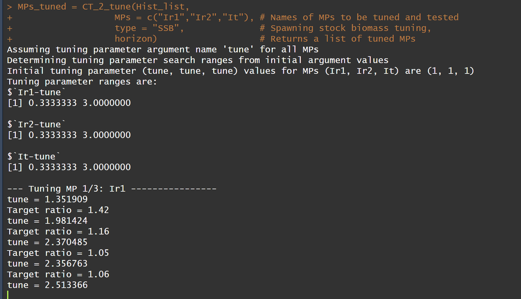

As the optimizer runs, it reports both the value of the tuning parameter (in this case ‘tune’) and the ratio of SSB in horizon years: SSB current (the ‘Target ratio’). When this ratio is close to 1 and the tuning parameter is changing less than the specified tolerance (user defined parameter ‘near_enough’ - the default is 1E-4), the optimizer stops and moves to the next MP.

If all MPs are tuned such that they are ‘near_enough’ to the target ratio of 1 (SSB_horizon ~= SSB_current) the tuning will end with output confirming that all MPs were tuned successfully:

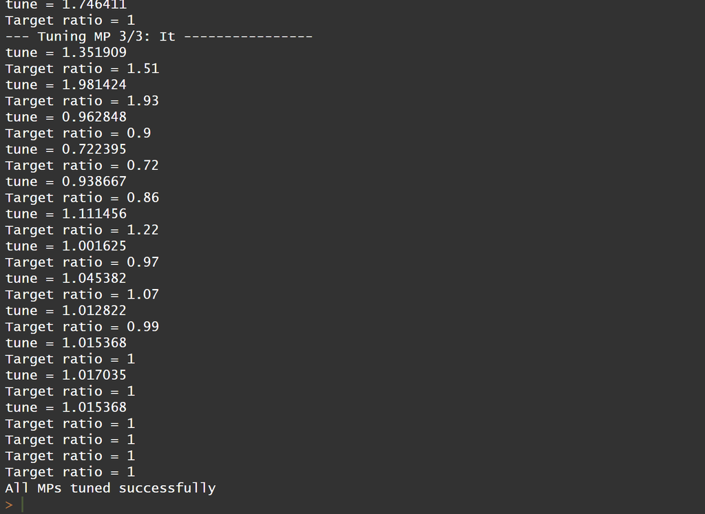

### 5.3.5 Step 3, Conduct Climate Tests

The tuned MPs are now projected for incrementally increasing climate tests.

```r
tests = c(S = 200,           # Up to 200% increase in catchability over the specified horizon
          M = 25,            # Up to 25% increases in natural mortality over the specified horizon
          R = 50,            # Up to 50% decreases in recruitment strength over the specified horizon
          K = 75,            # Up to 75% decreases in somatic growth over the specified horizon
          C = 75)            # Up to 75% decrease in condition factor (W / L^b) over the specified horizon

nlev = 8                     # Number of levels for each test (to interpolate over)

CT_data = CT_3_test(Hist_list,  # From Step 1
                 MPs_tuned,  # From Step 2
                 nlev, horizon, tests) # Over 8 increments for 30 projected years
```

Running the climate test is effectively running a very large number of projections. Lets say you have 5 tests and 8 levels of each test for 2 operating models, 3 MPs over 100 simulations and 35 projection years. That is 5 x 8 x 2 x 3 x 100 x 35 = 840,000 simulation-years of calculations. Some model-based MPs take time to run for each of these simulation-year combinations. You can first run a small (low simulation number, single OM) climate test to get an idea of the running time.

The test is run in parallel across the levels of each marginal test (8 levels by default) so providing you have enough threads that may not impact running time substantially.

Once the climate test has run you should see something like this output:

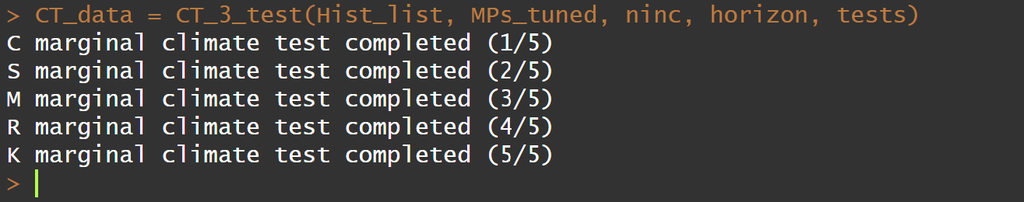

### 5.3.6 Step 4, Summarize Results

The results data arising from the test can be plotted and presented in various ways:

```r
# Raw results
results = CT_metrics(CT_data, horizon) # Calculate SSB and yield loss metrics
results$SSB_relative                # SSB loss metrics across tests and MPs
```

```
## $C
##              0  10.714  21.429  32.143  42.857  53.571  64.286      75
## Ir1_CT 1.00004 0.91549 0.81518 0.71008 0.61055 0.51931 0.45807 0.39847
## Ir2_CT 1.00041 0.94129 0.88453 0.87068 0.85126 0.82961 0.80831 0.79482
## It_CT  0.99930 0.89949 0.78687 0.69627 0.60343 0.55414 0.54809 0.54463
##
## $S
##              0  28.571  57.143  85.714 114.286 142.857 171.429     200
## Ir1_CT 1.00004 0.88435 0.80317 0.75763 0.72541 0.71178 0.70195 0.69220
## Ir2_CT 1.00041 0.82705 0.70300 0.60213 0.51097 0.42732 0.35750 0.29018
## It_CT  0.99930 0.85444 0.82748 0.80152 0.76913 0.73528 0.71918 0.71882
##
## $M
##              0   3.571   7.143  10.714  14.286  17.857  21.429      25
## Ir1_CT 1.00004 0.85923 0.72753 0.60313 0.49397 0.39326 0.30361 0.23668
## Ir2_CT 1.00041 0.87942 0.76290 0.66259 0.59118 0.52443 0.46238 0.40812
## It_CT  0.99930 0.84765 0.70444 0.57352 0.46821 0.37163 0.29788 0.24372
##
## $R
##              0   7.143  14.286  21.429  28.571  35.714  42.857      50
## Ir1_CT 1.00004 0.88866 0.79205 0.69487 0.61318 0.53911 0.46659 0.40214
## Ir2_CT 1.00041 0.90536 0.82138 0.74371 0.68687 0.64259 0.60249 0.56399
## It_CT  0.99930 0.88018 0.77301 0.67167 0.58096 0.50899 0.44262 0.38031
##
## $K
##              0  10.714  21.429  32.143  42.857  53.571  64.286      75
## Ir1_CT 1.00004 0.89357 0.76386 0.62411 0.49437 0.39095 0.32687 0.26271
## Ir2_CT 1.00041 0.92470 0.86214 0.83470 0.79973 0.76065 0.72512 0.68823
## It_CT  0.99930 0.87717 0.73308 0.60862 0.49706 0.46252 0.46416 0.46040
```

```r
# Robustness metrics
RT = 0.85                # Robustness threshold, when SSB drops below this fraction of starting SSB
tab = CT_tabulate(results$SSB_relative, RT)          # Calculate the test level where RT is crossed
dt = makeCTtab(tab)                                  # HTML table
dt
```

[interactive table not shown]

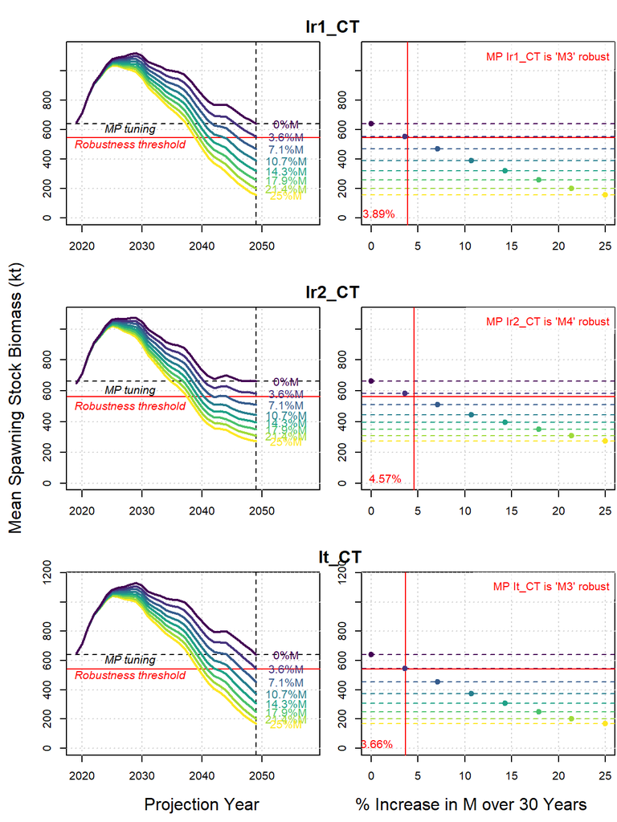

```r
CT_proj(CT_data, horizon, "M", RT = RT)              # Explanatory figure
```

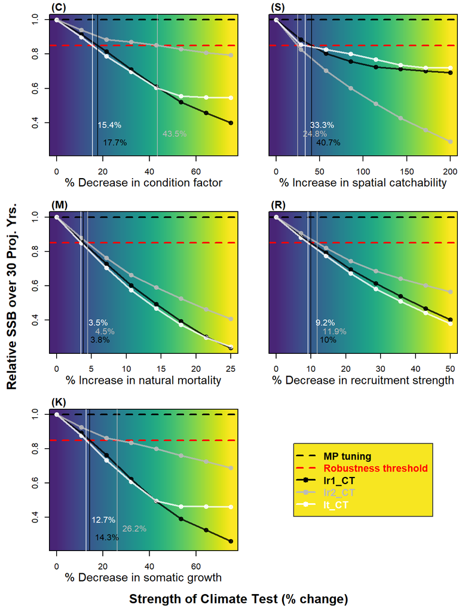

```r
CT_4_summary(CT_data, RT = RT, horizon = horizon)    # Summary figure
```

## 5.4 Exploratory Test For N. Atl. Swordfish

In this example we use a single reference set operating model from the North Atlantic Swordfish MSE (MOM_005), strip it to a small number of simulations for demonstration purposes, and then Climate Test the adopted MP (‘mostly constant catch’, MCC11_b, Duprey 2024) and a competing candidate MP assuming approximately constant exploitation rate (CE_b, Hordyk 2024)

### 5.4.1 Prerequisites

For this real-world application you will need to install the SWOMSE R package from github, and then load it and the ClimateTest package:

```r
install.packages('pak')                               # Install package management
pak::pkg_install('https://github.com/ICCAT/nswo-mse') # Install SWOMSE R package from ICCAT repo

library(SWOMSE)                                       # Load N. Atl. swordfish MSE library
library('ClimateTest')                                # ClimateTest functions and demo objects
```

### 5.4.2 Step 1, Prepare Operating Models

Here we take one of the swordfish multi-operating model objects (MOM_005) and reduce it to just the first 8 simulations so that the code runs fast enough for demonstration purposes. After which, all climate impacts are removed and the historical simulation is spooled-up using CT_1_prep.

```r
small_OM = SubCpars(MOM_005,1:8)
OM_list = list(small_OM)
Hist_list = CT_1_prep(OM_list) # Spool up with no climate effects
```

### 5.4.3 Step 2, Tune MPs

In step 2 we tune two empirical MPs, CE_b and MCC11_b, the latter being the MP adopted for use in N. Atl. Swordfish management. The projection runs for something like 32 years so we are using a 25 year horizon.

```r
horizon = 25
CE_b = ClimateTest::CE_b
MCC11_b = ClimateTest::MCC11_b
MPs_tuned = CT_2_tune(Hist_list,
                      MPs = c("CE_b","MCC11_b"),      # Names of MPs to be tuned and tested
                      MP_par_nams = rep("tunepar",2), # tuning parameter names for each MP
                      type = "SSB",                   # Spawning stock biomass tuning,
                      horizon,                        # Returns a list of tuned MPs
                      parallel=F)                     # No need to run in parallel (only 1 OM)
```

### 5.4.4 Step 3, Conduct Climate Tests

The spooled-up operating models (Hist_list) and the tuned MPs (MPs_tuned) are then used in the Climate Test. This is run in parallel across the various levels of each type of test (e.g., 8 levels of natural mortality rate increase (M) from 0 to 25% over 25 years). To make sure everthing needed is available to the cluster for parallel computation, we use the sfLibrary() function to export all SWOMSE functions and variables to the cluster:

```r
setup()                      # Initialize cluster for parallel computation
sfLibrary(SWOMSE)            # Send SWOMSE objects and functions to the cluster
tests = c(C = 75,            # Up to 75% decrease in condition factor (W / L^b)
          S = 200,           # Up to 200% increase in catchability
          M = 25,            # Up to 25% increases in natural mortality
          R = 50,            # Up to 50% decreases in recruitment strength
          K = 75)            # Up to 75% decreases in somatic growth

nlev = 8                     # Number of increments for each test (to interpolate over)

CT_data = CT_3_test(Hist_list, MPs_tuned, nlev, horizon, tests)
```

### 5.4.5 Step 4, Summarize Results

As before, the climate test outputs can be presented as tables or figures:

```r
RT = 0.8

results = CT_metrics(CT_data, horizon=horizon) # Calculate SSB and yield loss metrics
results$SSB_relative                           # SSB loss metrics

tab = CT_tabulate(results$SSB_relative, RT=RT) # Calculate the test level where RT is crossed
makeCTtab(tab)                                 # HTML table

CT_proj(CT_data, horizon, "M", RT=RT)          # Plot the projected SSB outcomes and test level

CT_4_summary(CT_data, RT = RT, horizon = horizon) # Summary plot of all tests
```

# 6 Recent Presentations

Developing the Climate Test: Robustness Trials for climate-ready management procedures. 2024 Ecosystems working group (online). SCRS/P/2024/104

Developing the Climate Test: Performance Metrics of Climate Robustness. 2024 species group meetings (Madrid / online). SCRS/P/2024/148

# 7 Climate Test Papers

[Carruthers, T.R.. 2024a. Developing the Climate Test: Robustness Trials for climate-ready management procedures. Col. Vol. Sci. Pap. ICCAT. 81(6): 1-26](https://www.iccat.int/Documents/CVSP/CV081_2024/n_6/CV08106104.pdf)

[Carruthers, T.R., 2024b. Developing the Climate Test: Performance Metrics of Climate Robustness. Col. Vol. Sci. Pap. ICCAT. 81(2): 1-7](https://www.iccat.int/Documents/CVSP/CV081_2024/n_2/CV08102148.pdf)

# 8 References

Algieri, B., Iania, L, Leccadito, A. 2023. Looking ahead: forecasting total energy carbon dioxide emissions. Cleaner Environmental Systems. 9. https://doi.org/10.1016/j.cesys.2023.100112

Atkinson D. 1994. Temperature and organism size—a biological law for ectotherms? Adv. Ecol. Res. 3:1–58

Banks, S. C., Ling, S. D., Johnson, C. R., Piggott, M. P., Williamson, J. E., and Beheregaray, L. B. 2010.

Genetic structure of a recent climate change-driven range extension. Mol. Ecol. 19, 2011–2024. doi: 10.1111/j.1365-294X.2010.04627.x

Bell, J.D., Johnson, J.E., Hobday, A.J. 2011. Vulnerability of Tropical Pacific Fisheries and Aquaculture to Climate Change. Secretariat of the Pacific Community, Noumea, New Caledonia.

Beaugrand, G. 2009. Decadal changes in climate and ecosystems in the North Atlantic Ocean and adjacent seas. Deep Sea Res. II Top. Stud. Oceanogr. 56, 656–673. doi: 10.1016/j.dsr2.2008.12.022

Beaugrand, G., Brander, K.M., Lindley, A.J., Souissi, S., Reid, P. C. 2003. Plankton effect on cod recruitment in the North Sea. Nature Letters. 426: 661 – 664.

Beaugrand, G., and Kirby, R. R. 2010. Spatial changes in the sensitivity of Atlantic cod to climate-driven effects in the plankton. Clim. Res. 41, 15–19. doi: 10.3354/cr00838

Beaugrand, G., Kirby, R.R. 2023. How do Marine Pelagic Species Respond to Climate Change? Theories and Observations. Annual Review of Marine Science. 2018 (10): 169-97. https://doi.org/10.1146/annurev-marine-121916063304

Bigg GR. 1996. The Oceans and Climate. Cambridge, UK: Cambridge Univ. Press

Brickman, D., Hebert, D., and Wang, Z. 2018. Mechanism for the recent ocean warming events on the Scotian Shelf of eastern Canada. Cont. Shelf Res. 156, 11–22. doi:10.1016/j.csr.2018.01.001

Bushnell, P. G., and Brill, R.W. 1991 Responses of swimming skipjack (Katsuwonus pelamis) and yellowfin (Thunnus albacares) tunas exposed to acute hypoxia, and a model of their cardiorespiratory function. Physiological Zoology. 64, 787–811.

Cai, W., Shi, G., Cowan, T., Bi, D. ,and Ribbe, J. 2005.The response of the Southern Annular Mode, the East Australian Current, and the southern mid-latitude ocean circulation to global warming. Geophys. Res. Lett. 32,L23706.doi:10.1029/2005GL024701

Cai, W.-J., Hu, X., Huang, W.-J., Murrell, M. C., Lehrter, J. C., Lohrenz, S. E., et al. 2011. Acidification of subsurface coastal waters enhanced by eutrophication. Nat. Geosci. 4, 766–770. doi: 10.1038/ngeo1297

Caldeira. K., Wickett, M.E. 2003. Anthropogenic carbon and ocean pH. Nature 425, 365.

Carruthers, T.R. and Hordyk, A.R. 2018. Using management strategy evaluation to establish indicators of changing fisheries. Canadian Journal of Fisheries and Aquatic Sciences. DOI: 10.1139/cjfas-2018-0223

Cayré, P.F., Marsac, F. 1993. Modelling the yellowfin tuna (Thunnus albacares) vertical distribution using sonic tagging results and local environmental parameters. Aquatic Living Resources 6, 1–14.

Chang, Y.-L., Sun, C.-L., Chen, Y., Yeh, S.-Z., DiNardo, G., and Su1, N.-J. 2013. Modelling the impacts of environmental variation on the habitat suitability of swordfish, Xiphias gladius, in the equatorial Atlantic Ocean. ICES J. Mar. Sci. 70, 1000–1012. doi: 10.1093/icesjms/fss190

Checkley, D.M. Jr, Dickson, A.G., Takahashi, I. M., Radich, J.A. et al. 2009. Elevated CO2 enhances growth in young fish. Science. 324, 1683.

Chevin, L. M., Collins, S., and Lefevre, F. 2013. Phenotypic plasticity and evolutionary demographic responses to climate change: taking theory out to the field. Funct. Ecol. 27, 966–979. doi: 10.1111/j.1365-2435.2012.02043.x

Chin, A., Kyne, P. M., Walker, T. I., and McAuley, R. B. 2010. An integrated risk assessment for climate change: analyzing the vulnerability of sharks and rays on Australia’s Great Barrier Reef. Glob. Change Biol. 16, 1936–1953. doi: 10.1111/j.1365-2486.2009.02128.x

Chown, S. L., Hoffmann, A. A., Kristensen, T. N., Angilletta, M. J., Stenseth, N. C., and Pertoldi, C. 2010. Adapting to climate change: a perspective from evolutionary physiology. Clim. Res. 43, 3–15. doi: 10.3354/cr00879

Collie, J.S., R.J. Bell, S.B. Collie, C. Minto. 2021. Harvest strategies for climate-resilient fisheries. ICES J. Mar. Sci., 78 (2021), pp. 2774-2783

Comiso JC, Parkinson CL, Gersten R, Stock L. 2008. Accelerated decline in the Arctic sea ice cover. Geophys. Res. Lett. 35:L01703

Courtney, D. 2016. PRELIMINARY STOCK SYNTHESIS (SS3) MODEL RUNS CONDUCTED FOR NORTH ATLANTIC BLUE SHARK. SCRS/2015/151. Collect. Vol. Sci. Pap. ICCAT, 72(5): 1186-1232.

Courtney, D., Cortes, E., and Zhang, X. 2017. STOCK SYNTHESIS (SS3) MODEL RUNS CONDUCTED FOR NORTH ATLANTIC SHORTFIN MAKO SHARK. SCRS/2017/125 Collect. Vol. Sci. Pap. ICCAT, 74(4): 1759-1821.

Crozier, L. G., and Hutchings, J. A. (2014). Plastic and evolutionary responses to climate change in fish. Evol. Appl. 7, 68–87. doi: 10.1111/eva.12135

Dell’Apa, A., Boenish, R., Fujita, R., Kleisner, K. 2023. Effects of climate change and variability on large pelagic fish in the Northwest Atlantic Ocean: implications for improving climate resilient management for pelagic longline fisheries. Front. Mar. Sci. 10. https://doi.org/10.3389/fmars.2023.1206911

Dell’Apa, A., Carney, K., Davenport, T. M., and Vernon Carle, M. 2018. Potential medium-term impacts of climate change on tuna and billfish in the Gulf of Mexico: A qualitative framework for management and conservation. Mar. Environ. Res. 141, 1–11. doi: 10.1016/j.marenvres.2018.07.017

Dickson R, Lazier J, Meincke J, Rhines P, Swift J. 1996. Long-term coordinated changes in the convective activity of the North Atlantic. Prog. Oceanogr. 38:241–95.

Doney S. C., Ruckelshaus M., Emmett Duffy J., Barry J. P., Chan F., English C. A., et al. 2012. Climate change impacts on marine ecosystems. Ann. Rev. Mar. Sci. 4, 11–37. doi: 10.1146/annurev-marine-041911-111611

Dulvy, N. K., Rogers, S. I., Jennings, S., Stelzenmuller, V., Dye, S. R., and Skjoldal, H. R. 2008. Climate change and deepening of the North Sea fish assemblage: a biotic indicator of warming seas. J. Appl. Ecol. 45, 1029–1039. doi: 10.1111/j.1365-2664.2008.01488.x

Edwards, M., Richardson, A.J. 2004. Impact of climate change on marine pelagic phenology and trophic mismatch. Nature Letters. 430 (881-884).

Erauskin-Extramiana, M., Arrizabalaga, H., Hobday, A. J., Cabré, A., Ibaibarriaga, L., Arregui, I., et al. 2019. Large-scale distribution of tuna species in a warming ocean.

Erauskin-Extramiana, M., Arrizabalaga, H., Cabré, A., Coelho, R., Rosa, D., Ibaibarriaga, L., et al. 2020. Are shifts in species distribution triggered by climate change? A swordfish case study. Deep Sea Res. 2 Top. Stud. Oceanogr. 175, 104666. doi: 10.1016/j.dsr2.2019.104666

Fincham, J. I., Rijnsdorp, A. D., and Engelhard, G. H. 2013. Shifts in the timing of spawning in sole linked to warming sea temperatures. J. Sea Res. 75, 69–76. doi: 10.1016/j.seares.2012.07.004

Feely RA, Doney SC, Cooley SR. 2009. Ocean acidification: present conditions and future changes in a high-CO2 world. Oceanography 22(4):36–47.

Free C. M., Thorson J. T., Pinsky M. L., Oken K. L., Wiedenmann J., Jensen O. P. 2019. Impacts of historical warming on marine fisheries production. Science 363, 979–983. doi: 10.1126/science.aau1758

Fuentes, M. M. P. B., Chambers, L., Chin, A., Dann, P., Dobbs, K., Marsh, H., et al. 2016. Adaptive management of marine mega-fauna in a changing climate. Mitig. Adapt. Strateg. Glob. Change 21, 209–224. doi: 10.1007/s11027-014-9590-3.

Fulton, E. A. (2011). Interesting times: winners, losers, and system shifts under climate change around Australia. ICES J. Mar. Sci. 68, 1329–1342. doi: 10.1093/icesjms/fsr032

Hare, J. A., Morrison, W. E., Nelson, M. W., Stachura, M., Teeters, E. J., Griffis, R. B., et al. 2016. A vulnerability assessment of fish and invertebrates to climate change on the Northeast U.S. Continental Shelf. PloS One 11, e0146756. doi: 10.1371/journal.pone.0146756

Hoegh-Guldberg O., Jacob D., Taylor M., Bindi M., Brown S., Camilloni I., et al. 2018. “Impacts of 1.5°C global warming on natural and human systems,” in Global Warming of 1.5°C An IPCC special report on the impacts of global warming of 1.5°C above pre-industrial levels and related global greenhouse gas emission pathways, in the context of strengthening the global response to the threat of climate change. Eds. Masson-Delmotte P. Z. V., Zhai P., Pörtner H. O., Roberts D., Skea J., Shukla P. R., et al (Geneva: IPCC), 175–311.

Hollowed, A.B, K.K. Holsman, A.C. Haynie, A.J. Hermann, A.E. Punt, K. Aydin, J.N. Ianelli, S. Kasperski, W. Cheng, A. Faig, K.A. Kearney, J.C.P. Reum, P. Spencer, I. Spies, W. Stockhausen, C.S. Szuwalski, G.A. Whitehouse, T.K. Wilderbuer. 2020. Integrated modeling to evaluate climate change impacts on coupled social-ecological systems in Alaska. Front. Mar. Sci., 6, p. 775

Hordyk, A.R., Huynh, Q.C., Carruthers, T.R. 2024. OpenMSE: open-source tools for management strategy evaluation. Available from: https://openmse.com/, https://github.com/Blue-Matter/openMSE and https://cran.r-project.org/package=openMSE.

Huynh, Q., Carruthers, T., Taylor, N.G. 2022. EcoTest: a proof of concept for evaluating ecological indicators in multispecies fisheries , with the Atlantic longline fishery case study. SCRS/2022/106.

Huynh, Q., Carruthers, T. 2023. Spatial distribution of multispecies longline catch per unit effort. SCRS/2023/037.

Hsieh, C. H., Reiss, C. S., Hewitt, R. P., and Sugihara, G. 2008. Spatial analysis shows that fishing enhances the climatic sensitivity of marine fishes. Can. J. Fish. Aquat. Sci. 65, 947–961. doi: 10.1139/f08-017

Essington, T.E. 2003. Development and sensitivity analysis of bioenergetics models for skipjack tuna and albacore: A comparison of alternative life histories. Transactions of the American Fisheries Society 132, 759–770.

Free, C.M., T. Mangin, J. Wiedenmann, C. Smith, H. McVeigh, S.D. Gaines. 2023. Harvest control rules used in US federal fisheries management and implications for climate resilience. Fish Fish., 24, pp. 248-262

Ganachaud, A.S., Gupta, A.S., Orr, J.C., Wijffels, S.E., Ridgway, K.R., Hemer, M.A., Maes, C., Steinberg, C.R., Triollet, A.D., Qiu, B., Kruger, J.C. 2011. “Observed and expected changes to the tropical Pacific Ocean” in Vulnerability of tropical pacific fisheries and aquaculture to climate change. Eds. Bell J., Johnson J. E., Hobday A. J. (Noumea: Secretariat of the Pacific Community), 101–187.

Gilly, W. F., Beman, J. M., Litvin, S. Y., and Robison, B. H. 2013. Oceanographic and biological effects of shoaling of the oxygen minimum zone. Ann. Rev. Mar. Sci. 5, 393–420. doi: 10.1146/annurev-marine-120710-100849.

Gooding, R.G., Neill, W.H. and Dizon, A.E. 1981. Respiration rates and low-oxygen tolerance limits in skipjack tuna, Katsuwonus pelamis. Fishery Bulletin US 79, 31–47.

Graham, J.B., Lowell, R.W., Lai N.C., Laurs, R.M. 1989. O2 tension, swimming velocity, and thermal effects on the metabolic rate of the Pacific albacore, Thunnus alalunga. Experimental Biology 48, 89–94.

Karnasuskas, M., Schirripa, M. J., Craig, J. K., Cook, G. S., Kelble, C. R., Agar, J. J., et al. 2015. Evidence of climate-driven ecosystem reorganization in the Gulf of Mexico. Glob. Change Biol. 21, 2554–2568. doi: 10.1111/gcb.12894

Karnauskas, M., Schirripa, M. J., Kelble, C. R., Cook, G. S., and Craig, J. K. 2013. Ecosystem status report for the Gulf of Mexico. NMFS-SEFSC-653, 52.

Kawamiya, M., Hajima, T., Tachiiri, K. et al. 2020. Two decades of Earth system modeling with an emphasis on Model for Interdisciplinary Research on Climate (MIROC). Prog Earth Planet Sci 7, 64. https://doi.org/10.1186/s40645-020-00369-5

Kwiatkowski L., Torres O., Bopp L., Aumont O., Chamberlain M., Christian J. R., et al. 2020. Twenty-first century ocean warming, acidification, deoxygenation, and upper ocean nutrient decline from CMIP6 model projections. Biogeosciences 17, 3439–3470. doi: 10.5194/bg-17-3439-2020.

Last, P. R., White, W. T., Gledhill, D. C., Hobday, A. J., Brown, R., Edgar, G. J., et al. (2011). Long-term shifts in abundance and distribution of a temperate fish fauna: a response to climate change and fishing practices. Glob. Ecol. Biogeogr. 20, 58–72. doi: 10.1111/j.1466-8238.2010.00575.x

Lehodey, P., Bertignac, M., Hampton J., Lewis, A., Picaut, J. (1997). El Niño Southern Oscillation and tuna in the western Pacific. Nature 389, 715–717. doi: 10.1038/39575.

Lehodey, P., Hampton, J., Brill, R. W., Nicol, S., Senina, I., Calmettes, B., et al. 2011. “Vulnerability of oceanic fisheries in the tropical Pacific to climate change,” in Vulnerability of tropical pacific fisheries and aquaculture to climate change. Eds. Bell J., Johnson J. E., Hobday A. J. (Noumea: Secretariat of the Pacific Community), 447–506.

Lehodey P, Murtugudde R and Senina I.2010. Bridging the gap from ocean models to population dynamics of large marine predators: A model of mid-trophic functional groups. Progress in Oceanography 84, 69–74.

Lehodey P., Senina I., Calmettes B., Hampton J., Nicol S. (2013). Modelling the impact of climate change on Pacific skipjack tuna population and fisheries. Clim. Change 119, 95–109. doi: 10.1007/s10584-012-0595-1

Lehodey P., Senina I., Nicol S., Hampton J. (2015). Modelling the impact of climate change on South Pacific albacore tuna. Deep Sea Res. 2 Top. Stud. Oceanogr. 113, 246–259. doi: 10.1016/j.dsr2.2014.10.028

Li, Y., Frantantoni, P. S., Chen, C., Hare, J. A., Sun, Y., Beardsley, R. C., et al. 2015. Spatio-temporal patterns of stratification on the Northwest Atlantic shelf. Prog. Oceanogr. 134, 123–137. doi: 10.1016/j.pocean.2015.01.003

Ling, S. D., Johnson, C. R., Frusher, S., and King, C. K. 2008. Reproductive potential of a marine ecosystem engineer at the edge of a newly expanded range. Glob. Chang. Biol. 14, 1–9. doi: 10.1111/j.1365-2486.2008.01543.x

Loder, J. W., and Wang, Z. (2015). Trends and variability of sea surface temperature in the Northwest Atlantic from three historical gridded datasets. Atmos. Ocean 53, 510–528. doi: 10.1080/07055900.2015.1071237

MacLeod, C.D. 2009. Global climate change, range changes and potential implications for the conservation of marine cetaceans: a review and synthesis. Endanger. Species Res. 7:125–36

Murawski, S.A. 1993. Climate change and marine fish distributions: forecasting from historical analogy. Trans. Am. Fish. Soc. 122(5): 647-658.

Nicol, S., Lehodey, P., Senina, I., Bromhead, D., Frommel, A. Y., Hampton, J., et al. 2022. Ocean futures for the world’s largest yellowfin tuna population under the combined effects of ocean warming and acidification. Front. Mar. Sci. 9, 816772. doi:10.3389/fmars.2022.816772

NMFS. 2020. Atlantic Highly Migratory Species Management-Based Research Needs and Priorities (Silver Spring, MD, United State: NMFS).

Neuheimer, A. B., Thresher, R. E., Lyle, J. M., and Semmens, J. M. 2011. Tolerance limit for fish growth exceeded by warming waters. Nat. Clim. Chang. 1, 110–113. doi: 10.1038/nclimate1084.

Nye J. A., Baker M. R., Bell R., Kenny A., Halimeda Kilbourne K., Friedland K. D., et al. 2014. Ecosystem effects of the Atlantic multidecadal oscillation. J. Mar. Syst. 133, 103–116. doi: 10.1016/j.jmarsys.2013.02.006

Nye, J. A., Link, J. S., Hare, J. A., and Overholtz, W. J. 2009. Changing spatial distribution of fish stocks in relation to climate and population size on the Northeast United States continental shelf. Mar. Ecol. Prog. Ser. 393, 111–129. doi: 10.3354/meps08220

O’Brien S. M., Gallucci V. F., Hauser L. 2013. Effects of species biology on the historical demography of sharks and their implications for likely consequences of contemporary climate change. Conserv. Genet. 14, 125–144. doi: 10.1007/s10592-012-0437-8

O’Connor, M. I., Holding, J. M., Kappel, C. V., Duarte, C. M., Brander, K., Brown, C. J., et al. 2014. Strengthening confidence in climate change impact science. Glob. Ecol. Biogeogr. 24, 64–76. doi: 10.1111/geb.12218

Pacoureau, N., Rigby, C. L., Kyne, P. M., Sherley, R. B., Winker, H., Carlson, J. K., et al. 2021. Half a century of global decline in oceanic sharks and rays. Nature. 589, 567–571. doi: 10.1038/s41586-020-03173-9

Parsons, L. S., and Lear, W. H. 2001. Climate variability and marine ecosystem impacts: a North Atlantic perspective. Prog. Oceanogr. 49, 167–188. doi: 10.1016/ S0079-6611(01)00021-0

Pereira Campos, C., Bitar, S. D. B., and Freitas, C. (2023). Uncertainties regarding the natural mortality of fish can increase due global climate change. PeerJ 11, e14989. doi: 10.7717/peerj.14989

Perry, A.I., Low, P.J., Ellis, J. R., Reynolds, J.D. 2005. Climate change and distribution shifts in marine fishes. Science 308:1912–15.

Pinsky, M. L., Worm, B., Fogarty, M. J., Sarmiento, J. L., and Levin, S. A. 2013. Marine taxa track local climate velocities. Science 341, 1239–1242. doi: 10.1126/science.1239352

Pistevos, J. C. A., Nagelkerken, I., Rossi, T., Olmos, M., and Connell, S. D. 2015. Ocean acidification and global warming impair shark hunting behaviour and growth. Sci. Rep. 5, 16293. doi: 10.1038/srep16293

Podestá, G. P., Browder, J. A., and Hoey, J. J. 1993. Exploring the association between swordfish catch rates and thermal fronts on U.S. longline grounds in the western North Atlantic. Cont. Shelf Res. 13, 253–277. doi: 10.1016/0278-4343(93) 90109-B

Pollock, M. S., Clarke, L. M. J., and Dubé, M. G. 2007. The effects of hypoxia on fishes: from ecological relevance to physiological effects. Env. Rev. 15, 1–14. doi:10.1139/a06-006

Poloczanska, E. S., Hawkins, S. J., Southward, A. J., and Burrows, M. T. 2008. Modeling the response of populations of competing species to climate change. Ecology 89, 3138–3149. doi: 10.1890/07-1169.1

Poloczanska, E. S., Brown, C. J., Sydeman, W. J., Kiessling, W., Schoeman, D. S., Moore, P. J., et al. 2013. Global imprint of climate change on marine life. Nat. Clim. Chang. 3, 919–925. doi: 10.1038/nclimate1958

Poloczanska, E. S., Burrows, M. T., Brown, C. J., Garcı́a Molinos, J., Halpern, B. S.,Hoegh-Guldberg, O., et al. 2016. Responses of marine organisms to climate change across oceans. Front. Mar. Sci. 3, 62. doi: 103389/fmars.2016.00062

Pörtner, H. O., and Knust, R. 2007. Climate change affects marine fishes through the oxygen limitation of thermal tolerance. Science 315, 95–97. doi: 10.1126/science.1135471.

Pörtner, H. O., and Peck, M. A. (2010). Climate change effects on fishes and fisheries: towards a cause-and-effect understanding. J. Fish Biol. 77, 1745–1779. doi: 10.1111/j.1095-8649.2010.02783.x

Punt, A.E., Butterworth, D.S., de Moor, C.L., De Oliveira, J.A.A., and Haddon, M. 2016. Management strategy evaluation: Best practices. Fish Fish. 17(2): 303–334. doi:10.1111/faf.12104.

Punt, A.E., Dalton, M.G., Adams, G.D., Barbeaux, S.J., Cheng, W., Her-mann, A.J., Holsman, K.K., Hulson, P.J.F., Hurst, T.P., Rovellini, A. 2023. Capturing uncertainty when modelling environmental drivers of fish populations, with an illustrative application to Pacific Cod in the eastern Bering Sea. Fisheries Research. 272(106951)

Ravier, C., Fromentin, J. M. 2004. Are the long-term fluctuations in Atlantic bluefin tuna (Thunnus thynnus) population related to environmental changes? Fish. Oceanogr. 13, 145–160. doi: 10.1111/j.1365-2419.2004.00284.x

Rijnsdorp, A. D., Peck, M. A., Engelhard, G. H., Mollmann, C., and Pinnegar, J. K. 2009. Resolving the effect of climate change on fish populations. ICES J. Mar. Sci. 66, 1570–1583. doi: 10.1093/icesjms/fsp056

Sarmiento JL, Slater R, Barber R, Bopp L, Doney SC, et al. 2004. Response of ocean ecosystems to climate warming. Glob. Biogeochem. Cycles 18:1–23

Schirripa, M. 2018. CURRENT STATUS OF THE BLUE MARLIN (MAKAIRA NIGRICANS) STOCK IN THE ATLANTIC OCEAN 2018: PRE-DECISIONAL STOCK ASSESSMENT MODEL. SCRS/2018/097. Collect. Vol. Sci. Pap. ICCAT, 75(5): 1026-1050.

Schirripa, M. 2020. CURRENT STATUS OF THE WHITE MARLIN (KAJIKIA ALBIDA) STOCK IN THE ATLANTIC OCEAN 2019: PREDECISIONAL STOCK ASSESSEMENT MODEL. SCRS/2019/110. Collect. Vol. Sci. Pap. ICCAT, 76(4): 265-292.

Schirripa, M.J. and Hordyk, A. 2020. MIGRATING THE NORTH ATLANTIC SWORDFISH STOCK ASSESSMENT MODEL TO AN UPDATED VERSION OF STOCK SYNTHESIS WITH ANALYSIS OF THE CURRENT MINIMUM SIZE REGULATION. SCRS/2020/159 Collect. Vol. Sci. Pap. ICCAT, 77(3): 654-668.

Skubel, R. A., Kirtman, B. P., Fallows, C., and Hammerschlag, N. 2018. Patterns of long-term climate variability and predation rates by a marine apex predator, the white shark. Carcharodon carcharias. Mar. Ecol. Progr. Ser. 587, 129–139. doi: 10.3354/meps12424

Stendardo, I., and Gruber, N. 2012. Oxygen trends over five decades in the North Atlantic. J. Geophys. Res. 117, C11004. doi: 10.1029/2012JC007909

Stramma, L., Prince, E. D., Schmidtko, S., Luo, J., Hoolihan, J. P., Visbeck, M., et al. 2012. Expansion of oxygen minimum zones may reduce available habitat for tropical pelagic fishes. Nat. Clim. Change 2, 33–37. doi: 10.1038/nclimate1304

Stramma, L., Schmidtko, S., Levin, L. A., and Johnson, G. C. 2010. Ocean oxygen minima expansions and their biological impacts. Deep Sea Res. I Oceanogr. Res. 57, 587–595. doi: 10.1016/j.dsr.2010.01.005

Sydeman, W. J., García-Reyes, M., Schoeman, D. S., Rykaczewski, R. R., Thompson, S. A., Black, B. A., et al. 2014. Climate change and wind intensification in coastal upwelling ecosystems. Science 345, 77–80. doi: 10.1126/science.1251635

Tanaka, K. R., Van Houtan, K. S., Mailander, E., Dias, B. S., Galginaitis, C., O’Sullivan, J., et al. 2021. North Pacific warming shifts the juvenile range of a marine apex predator. Sci. Rep. 113373. doi: 10.1038/s41598-021-82424-9

Thomas C.D. 2010. Climate, climate change and range boundaries. Divers. Distrib. 16:488–95

Thomas C.D., Cameron A., Green R.E., Bakkenes M., Beaumont L.J., et al. 2004. Extinction risk from climate change. Nature 427:145–48.

Walther G. R., Post E., Convey P., Menzel A., Parmesan C., Beebee T. J. C., et al. 2002. Ecological responses to recent climate change. Nature 416, 389–395. doi: 10.1038/416389a

Wang, J., Wu, C., Liu, C., Gu, G. 2017. Integrated Assessment models of climate change economics. Springer. Singapore.

Wethey, D. S., and Woodin, S. A. 2008. Ecological hindcasting of biogeographic responses to climate change in the European intertidal zone. Hydrobiologia 606, 139–151. doi: 10.1007/s10750-008-9338-8

Wu, L.X., Cai, W. J., Zhang, L. P., Nakamura, H., Timmermann, A., Joyce, T., et al. 2012 . Enhanced warming over the global subtropical western boundary currents. Nat. Clim. Chang. 2,161–166.doi:10.1038/nclimate1353

Zymaroieva, A., Bondarev, D. & Kunakh, O, Svenning, J.C., Zhukov, O. 2024. Young-of-the-year fish as bioindicators of eutrophication and temperature regime of water bodies. Environmental Monitoring and Assessment. 196. 10.1007/s10661-024-12313-x.

# 9 Acknowledgements

ClimateTest is funded by:

The Paul M. Angell Family Foundation Oceankind The Pew Charitable Trusts

and

The Ocean Foundation in partnership with [www.HarvestStrategies.org](https://harveststrategies.org/)